# AS2018485-Uzbekistan

M.P.T Perera

9/24/2021

# **COVID-19 PANDEMIC IN UZBEKISTAN**

## **1. Introduction**

### 1.1 Visualization of the location.

Uzbekistan, officially Republic of Uzbekistan, Uzbek Ŭzbekiston or Ŭzbekistan Respublikasi, country in Central Asia. It lies mainly between two major rivers, the Syr Darya (ancient Jaxartes River) to the northeast and the Amu Darya (ancient Oxus River) to the southwest, though they only partly form its boundaries. Uzbekistan is bordered by Kazakhstan to the northwest and north, Kyrgyzstan and Tajikistan to the east and southeast, Afghanistan to the south, and Turkmenistan to the southwest. The autonomous republic of Qoraqalpoghiston (Karakalpakstan) is located in the western third of the country. The Soviet government established the Uzbek Soviet Socialist Republic as a constituent (union) republic of the U.S.S.R. in 1924. Uzbekistan declared its independence from the Soviet Union on August 31, 1991. The capital is Tashkent (Toshkent).

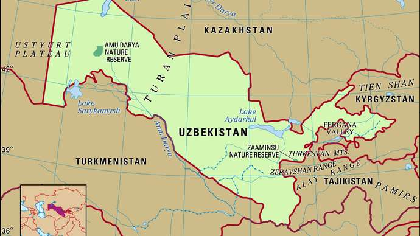

Nearly four-fifths of Uzbekistan’s territory, the sun-dried western area, has the appearance of a wasteland. In the northwest the Turan Plain rises 200 to 300 feet (60 to 90 metres) above sea level around the Aral Sea in Karakalpakstan (Qoraqalpog’iston). This terrain merges on the south with the Kyzylkum (Uzbek: Qizilqum) Desert and farther west becomes the Ustyurt Plateau, a region of low ridges, salt marshes, sinkholes, and caverns.

Southeast of the Aral Sea, small hills break the flatness of the low-lying Kyzylkum Desert, and, much farther east, a series of mountain ridges partition Uzbekistan’s territory. The western Tien Shan includes the Karzhantau, Ugam, and Pskem ranges, the latter featuring the 14,104-foot (4,299-metre) Beshtor Peak, the country’s highest point. Also part of the western Tien Shan are the Chatkal and Kurama ranges. The Gissar (Hissar) and Alay ranges stand across the Fergana (Farghona) Valley, which lies south of the western Tien Shan. The Mirzachol desert, southwest of Tashkent, lies between the Tien Shan spurs to the north and the Turkestan, Malguzar, and Nuratau ranges to the south. In south-central Uzbekistan the Zeravshan valley opens westward; the cities of Samarkand (Samarqand) and Bukhara (Bukhoro) grace this ancient cultural centre.

### 1.2 Climate condition.

Marked aridity and much sunshine characterize the region, with rainfall averaging only 8 inches (200 mm) annually. Most rain falls in winter and spring, with higher levels in the mountains and minimal amounts over deserts. The average July temperature is 90 °F (32 °C), but daytime air temperatures in Tashkent and elsewhere frequently surpass 104 °F (40 °C). Bukhara’s high summer heat contrasts with the cooler temperatures in the mountains. In order to accommodate to these patterns, Uzbeks favour houses with windows facing away from the sun but open to porches and tree-filled courtyards shut off from the streets.

Although more than 600 streams crisscross Uzbekistan, the climate strongly affects drainage, because river water rapidly escapes through evaporation and filtration or runs off into irrigation systems.

### 1.3 Lockdown status of the country.

On July 8, the government of Uzbekistan announced a second nationwide lockdown would begin on July 10 and run through August 1. The decision comes three days after Kazakhstan began its own second lockdown regime amid mounting cases of COVID-19, the disease caused by the novel coronavirus. Both of Central Asia’s largest states face similar tensions

Per official statistics, Uzbekistan has confirmed 10,982 cases of COVID-19 since marking its first case in mid-March. For comparison and contemplation: Neighboring Kazakhstan, a much larger country in territorial terms and much smaller in population terms, surpassed the 50,000 confirmed case mark in recent days. Kazakhstan has an estimated population of 18.7 million; Uzbekistan’s population is around 34 million.

Uzbek officials have denied allegations of purposeful underreporting of cases. Tashkent was relatively quick to lock the country off and down in March, closing its borders and rolling out restrictions. As Umida Hashimova outlined at the time, despite the reform program under President Shavkat Mirziyoyev, it was not much of a stretch for Uzbekistan to snap back into using heavy-handed, security-service forward tactics to enforce discipline.

But the social and economic bite of the pandemic, as in Kazakhstan, pushed Uzbekistan to move toward reopening. A study conducted by the United Nations Development Program (UNDP) released earlier this week highlighted the pandemic’s economic impact: Exports dropped 18 percent in the first quarter; 85 percent of the country’s small businesses were forced to close in March; the percentage of households with at least one member actively working fell from 85 to 43 percent.

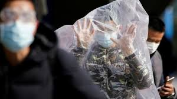

### 1.5 Actions taken by the government.

Since March 2020, the global COVID-19 pandemic, along with the world economies has had a negative impact on Central Asian countries, including Uzbekistan. The pandemic and economic crisis have affected national healthcare systems, public sectors, business activity, consumption, international trade and investment both on a human and an economic level all over the world. In Uzbekistan, for instance, the largest decline in economic activity during the quarantine period took place in the first ten days of April, when the volume of trades on the commodity exchange fell by an average of 30 per cent, and sales of some goods by up to 80 per cent. Between April 1st and 27th, compared to the same period in March, the total cash receipts in the country decreased by 45 per cent, while revenues from sales of products decreased by 31 per cent and revenues from paid services by almost 2.7 times.In these circumstances, Uzbekistan has been taking certain actions to mitigate the impact of the coronavirus pandemic and the global economic crisis on economic growth.

The first case of coronavirus infection was detected in Uzbekistan on March 15th in 2020, spurring the leadership to take immediate measures against the COVID-19 outbreak to curb the spread of the virus in the country. First of all, the Republican Anti-Crisis Commission of high-level government officials was established and headed by Prime Minister Abdulla Aripov. As part of the quarantine measures, the Commission urgently announced a strict quarantine regime on almost the whole territory of the country. Public health measures were the first step to control the spread of the virus among the population. Economic measures were the second step to maintain national business activity. The initial and second packages of economic support for the public and economic sectors, including household and business entities totalled 32.3 trillion soms.Moreover, a number of measures are being implemented to encourage economic activity in the country, to ensure social support for the population, optimise budget expenditures, and to support the most affected areas. As of May 30th 2020, more than 500,000 business entities and more than eight million citizens have received benefits and preferences in the amount of about 30 trillion soms, or about $3 billion (six per cent of GDP).

In general, Uzbekistan’s action plan to combat the current and future consequences of the global COVID-19 pandemic can be divided into four areas:

- General economic measures.
- Measures of social support for the population.
- Measures to support entrepreneurship.
- Measures to support the most affected sectors.

**General economic measures**

As noted above, the Anti-Crisis Fund was the first economy-wide step to mitigate the negative impact of the pandemic on the country’s economy. As of June 17th 2020, the income of the Fund (ten trillion soms) amounted to 7.44 trillion soms. That is, 74.4 per cent of its total amount was formed by June 17th. Of these, 7.32 trillion soms are allocations from international financial institutions, 123.5 billion soms have been channeled from the state budget, and the total amount of expenditures amounted to 3.3 trillion soms.The funds were spent as follows:

- 43 per cent went to support the economy, including thermal power plants, regional power networks, oil and gas networks, air transport and rubber industry.
- 17.6 per cent accounted for the Republican Agency for Sanitary and Epidemiological Well-Being for the purchase of test systems, reagents, and protective equipment, the cost of disinfection, the purchase of special equipment, etc.
- 15.5 per cent went for water supply and irrigation activities.
- 14.9 per cent was spent for the construction and equipping of hospitals and quarantine complexes.
- Nine per cent of the funds went to engaging unemployed citizens in the social area for temporary work, social benefits, to support women in low-income families, the development of personal subsistence plots for the unemployed, low-income families, and for workers of enterprises providing transport services.
- $5 million for the implementation of measures to strengthen the health system.
- $700 million to support entrepreneurship and the banking system.
- $1.7 billion and 150 million euros are allocated to build a resource base of the Anti-Crisis Fund and support the State Budget.
- $300 million is allocated to ensure the smooth functioning of the utilities and energy enterprises.
- $30.6 million is allocated for grants for various purposes, including grants from the United Arab Emirates for the construction of a children’s clinic in Tashkent, additional grants from the EU, the Government of Korea and international organisations for the purchase of medical equipment and supplies.

**Social support measures**

With the introduction of quarantine measures due to the coronavirus pandemic in Uzbekistan, the main focus fell on measures of social support for the population.

- First of all, Uzbekistan took action to prevent a decrease in the income of the population, sustain employment, and prevent unemployment. Specifically, it was noted that employers can transfer employees, especially pregnant women, the elderly, people with disabilities and chronic diseases, with their consent, to the convenient work schedule or to home-based work.
- During the suspension of the activities of preschool education institutions and secondary schools, one of the parents of primary school students were granted annual leave regardless of their annual leave schedule (including persons who have worked for less than six months).
- Parents placed in quarantine, as well as persons caring for their children, are paid temporary disability benefits in the amount of 100 per cent of the average monthly salary.
- Employers are prohibited to terminate employment contracts with the employees infected with coronavirus infection or quarantined, as well as with parents of a child under the age of 14. The amount of tax-free financial assistance has been almost doubled.

Also, given the fact that the majority of the affected population live in rural areas, close attention has been paid to the broad involvement of the population in seasonal work, taking into account the inaccessibility of rural areas, to the support of agricultural cooperatives, the creation of new areas and additional jobs, the development of withdrawn lands, to the creation of cooperatives, the commissioning of greenhouses in private households, to the establishment of irrigation systems on undeveloped lands, and other initiatives.

- Nextly measures have been taken to support retirees, single and lonely, and people with disabilities. The most important steps in this direction include the possibility for working pensioners to receive a two-month pension at a time, as well as the free provision of disposable masks, antiseptic and antibacterial fluids to lonely elderly people and persons with disabilities.
- The charitable funds of five million USD were also allocated by Alisher Usmanov. Funds and goods (including services) that are donated to Mahalla, Sahovat va Kumak, or Mercy, and Health of Uzbekistan public foundations, as well as to individuals in need of social support, were exempted from the income tax.
- To prevent food price hikes and reserve the necessary volumes of food products, Uzbekistan has taken appropriate measures. Prices for socially important food products in the markets and artificial price increases are monitored and controlled daily to prevent artificial shortages and excessive demand.

**Action to Support Entrepreneurship**

Phased use of economic sectors, rehabilitation of enterprises, and an increase in exports of finished products have become a pivotal priority during the new coronavirus pandemic. Therefore, Uzbekistan has taken large-scale measures to stimulate economic growth and investment activity, to restore production rates.

First, Uzbekistan took the following organisational measures:

- Expanded capacities of remote (online) services for taxpayers to fulfill their tax obligations without visiting state tax authorities by using electronic means of communications starting from simple phones calls to using web portal extensions.
- The deadline for submitting a declaration on the total annual income of individuals was extended (from April 1st to August 1st).
- A moratorium on tax audits has been announced until the end of 2020; and
- A moratorium was announced on the initiation of bankruptcy proceedings and on the declaration of enterprises experiencing financial difficulties as bankrupt (until October 1st 2020).
- Specifically, taking measures not to calculate fines against legal entities experiencing temporary difficulties for non-payment of property tax, land tax,and tax for the use of water resources and, also, not to enforce collection of tax debt (until October 1st).
- The application of penalties to business entities for overdue receivables from foreign trade operations was suspended (until October 1st); and
- The application of increased property tax and land tax rates for idle production facilities and non-residential premises has been suspended. They were also assigned to suspend the charging of interest and the enforcement of debts. This measure was applied to almost 21,000 enterprises.
- The minimum monthly amount of social tax for individual entrepreneurs has been reduced twice.
- leasing companies have been provided with rental benefits and some amenities. The calculation and collection of rent for the use of state property by entrepreneurs forced to cease their activities have been suspended.
- measures have been taken to support exports. Uzbekistan has promptly introduced the mechanism of customs clearance of imported food products, including by issuing permits before entering the territory of the Republic of Uzbekistan.

**Measures to Support the Most Affected Sectors**

- First, to support tourism and its directly related industries Uzbekistan has taken measures to preserve hundreds of thousands of jobs and qualified specialists, and maintain their income.
- Tour operators, travel agents, and hotel service entities, Uzbekistan Airports JSC, Uzbekistan Airways State Unitary Enterprise, and Uzaeronavigatsiya Center SUE have been exempted from property and land taxes (until the end of 2020), and the social tax rate was reduced to one per cent.

Also, to support this area, their organisational and economic sources have been identified:

- For the tourism sector, it is planned to allocate more than 20 billion soms from the Anti-Crisis Fund.
- At the expense of the Tourism Support Fund, it is planned to allocate one-time targeted interest-free loans for 12 months.
- 5 billion soms have been allocated to support start-up projects, innovative business ideas, information programs, and services in the tourism sector. It is envisaged to grant up to 100 million soms for projects on organising foreign cuisines, thematic food outlets, as well as food and souvenir delivery services.
- To further support textile enterprises and clusters, increase the competitiveness of products, the republic transited to international exchange prices, which made it possible to reduce raw material prices by ten per cent
- 64 types of imported raw materials essential for the textile industry have been exempted from customs duties (until January 1st 2022).

Uzbekistan has introduced a simplified procedure (until December 31st 2020), which provides for a full refund of value-added tax on products exported by textile enterprises. That is, as the products of textile enterprises leave the republic, the value-added tax will be fully refunded. It also envisioned drastically scaling up exports of finished products, establishing up-to-date large textile and sewing clusters under the international brand, employing at least a thousand people. Due to timely action, the activity of enterprises has been resumed in Uzbekistan, all jobs have been saved, and production and export volumes continue to grow.

## **2. Data Exploratory**

### **2.1 Structure of Data**

The data set used for this analysis is The 2019 Novel Coronavirus COVID-19 (2019-nCoV) Dataset which is easily available as an installable package in RStudio. The source of this data is Johns Hopkins University Center for Systems Science and Engineering (JHU CCSE) Coronavirus.

The dataset contains the daily summary of Coronavirus cases worldwide. All cases are recorded according to the following variables;

1. Date
2. Country 3.Province/state; if available 4.Latitude of center of geographic region defined by country/province
3. Longtitude of center of geographic region defined by country/province
4. Type of reported case – confirmed, death, recovered
5. Number of cases on given date

The analysis has been done by R, a programming language for statistical computing and graphics.

Here is the coronavirus dataframe.

```r
library(coronavirus)
data(coronavirus)
head(coronavirus)
```

```
        date province country     lat      long      type cases
1 2020-01-22  Alberta  Canada 53.9333 -116.5765 confirmed     0
2 2020-01-23  Alberta  Canada 53.9333 -116.5765 confirmed     0
3 2020-01-24  Alberta  Canada 53.9333 -116.5765 confirmed     0
4 2020-01-25  Alberta  Canada 53.9333 -116.5765 confirmed     0
5 2020-01-26  Alberta  Canada 53.9333 -116.5765 confirmed     0
6 2020-01-27  Alberta  Canada 53.9333 -116.5765 confirmed     0
```

There are 195 countries in this data set. This is a summary of the Uzbekistan coronavirus data.First, coronavirus data of Uzbekistan was extracted from coronvirus data set as below.

```r
library(tidyverse)
library(magrittr)

Uzbekistan_corona <- coronavirus %>% filter(country == "Uzbekistan")
Uzbekistan_corona_2 <- Uzbekistan_corona %>%
  pivot_wider(names_from = type,values_from = cases)

Uzbekistan_corona_new<-Uzbekistan_corona_2[!is.na(Uzbekistan_corona_2$recovered),]%>%
  pivot_longer(6:8,names_to = "type",values_to = "cases")#removed missing values

head(Uzbekistan_corona_new)
```

```
# A tibble: 6 x 7
  date       province country      lat  long type      cases
  <date>     <chr>    <chr>      <dbl> <dbl> <chr>     <int>
1 2020-01-22 <NA>     Uzbekistan  41.4  64.6 confirmed     0
2 2020-01-22 <NA>     Uzbekistan  41.4  64.6 death         0
3 2020-01-22 <NA>     Uzbekistan  41.4  64.6 recovered     0
4 2020-01-23 <NA>     Uzbekistan  41.4  64.6 confirmed     0
5 2020-01-23 <NA>     Uzbekistan  41.4  64.6 death         0
6 2020-01-23 <NA>     Uzbekistan  41.4  64.6 recovered     0
```

```r
summary(Uzbekistan_corona_new)
```

```
      date              province           country               lat
 Min.   :2020-01-22   Length:1683        Length:1683        Min.   :41.38
 1st Qu.:2020-06-10   Class :character   Class :character   1st Qu.:41.38
 Median :2020-10-28   Mode  :character   Mode  :character   Median :41.38
 Mean   :2020-10-28                                         Mean   :41.38
 3rd Qu.:2021-03-17                                         3rd Qu.:41.38
 Max.   :2021-08-04                                         Max.   :41.38
      long           type               cases
 Min.   :64.59   Length:1683        Min.   :   0.0
 1st Qu.:64.59   Class :character   1st Qu.:   0.0
 Median :64.59   Mode  :character   Median :  40.0
 Mean   :64.59                      Mean   : 154.6
 3rd Qu.:64.59                      3rd Qu.: 251.0
 Max.   :64.59                      Max.   :1955.0
```

In the world map Uzbekistan can be shown as below.

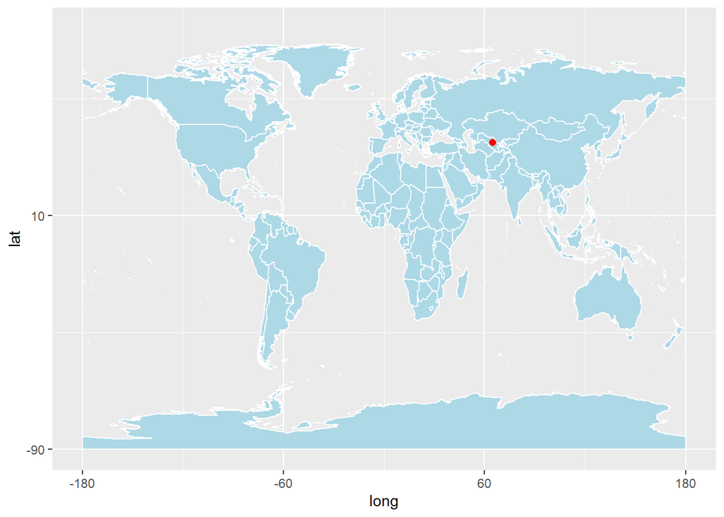

### **2.2 summary of cases in Uzbekistan**

```
# A tibble: 1 x 3
  confirmed death recovered
      <int> <int>     <int>
1    132901   901    126377
```

Active cases can be identify as ((active=confirmed-death-recovered)) 5623.

### **2.3 Visualization of corona virus cases in Uzbekistan.**

#### 2.3.1 Visualization of COVID-19 confirmed cases in Uzbekistan.

Represents the confirmed coronavirus cases in Uzbekistan.

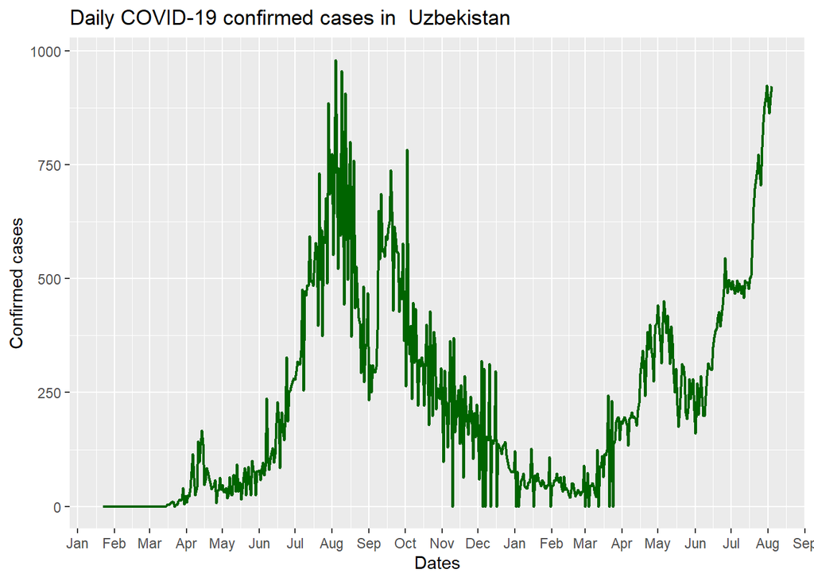

Figure 01: Daily COVID-19 confirmed cases in Uzbekistan.

#### 2.3.2 Visualization of COVID-19 death cases in Uzbekistan

Represents the daily death cases in Uzbekistan.

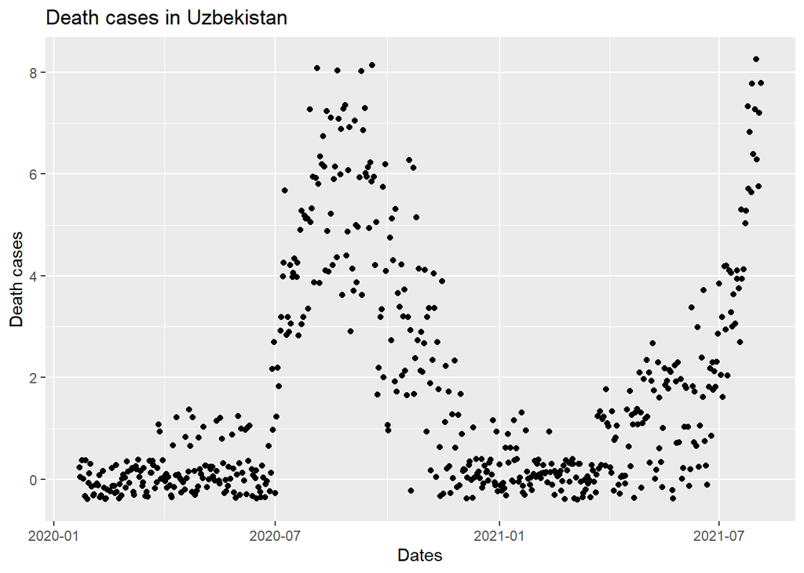

Figure 02: Daily COVID-19 death cases in Uzbekistan.

#### 2.3.3 Visualization of recovered cases in Uzbekistan.

Represents the recovered cases in Uzbekistan.

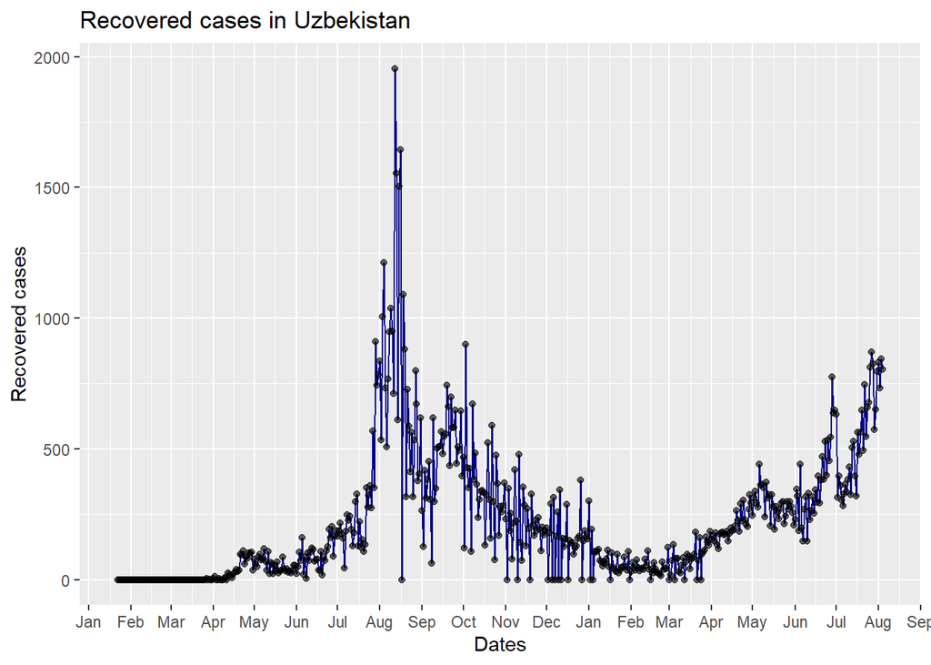

Figure 03:Time series plot of recovered cases in Uzbekistan.

#### 2.3.4 Visualization of Active cases in Uzbekistan.

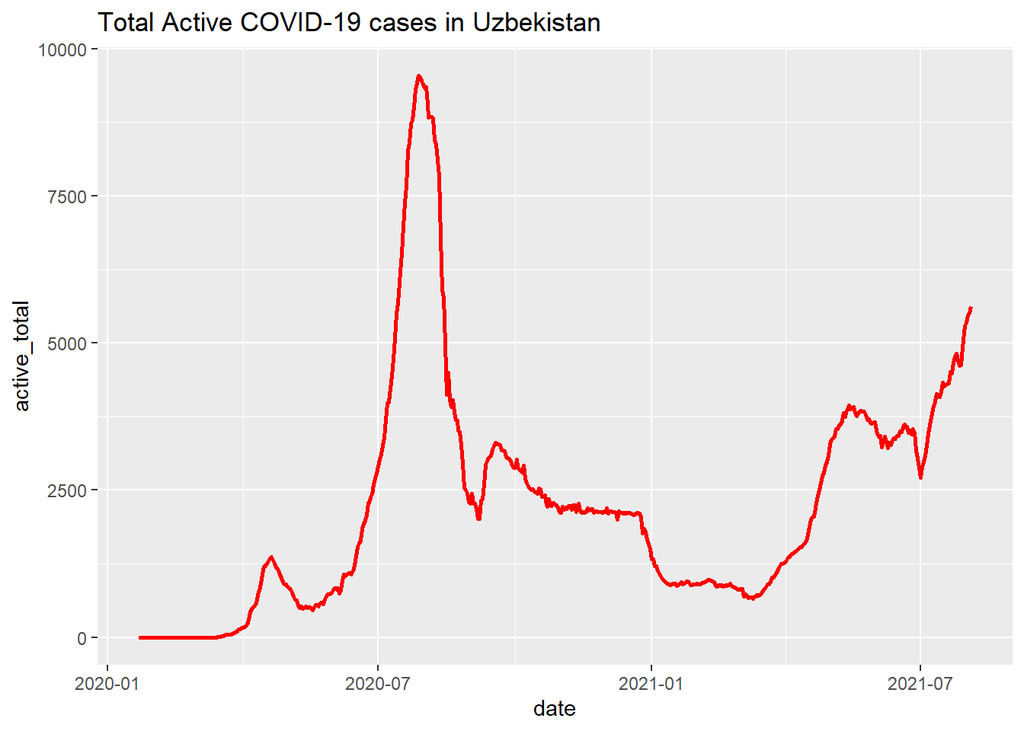

Figure 04: Total number of Active COVID-19 cases in Uzbekistan.

The confirmed, death and recovered COVID-19 cases in Uzbekistan can be shown in a one graph.

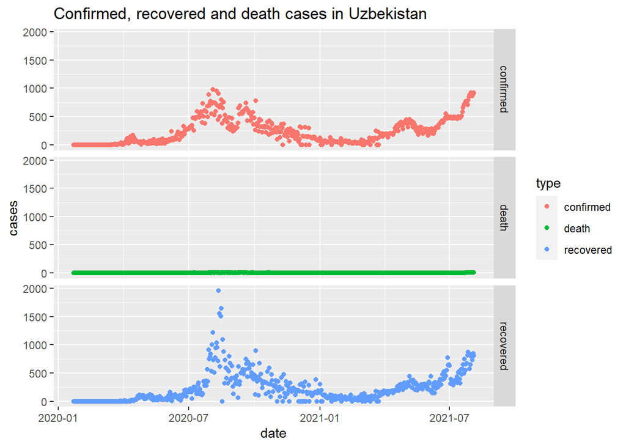

Figure 05: Daily COVID-19 confirmed, recovered and death cases in Uzbekistan.

According to that the daily confirmed and recovered cases have inreased in same period and both are in same pattern.As we can see in this graph The death cases are very low compared to confirmed cases and recovered cases distribution.

### **2.4 Comparing the COVID-19 cases with other countries.**

Uzbekistan is bordered by five countries. Kazakhstan to the north, Kyrgystan to the northeast,Tajikistan to the southeast, Afghanistan to the south, Turkmenistan to the southwest.And also Uzbekistan is a central asia country including above mention countries.Furthermore Russia,China Afghanistan and Iran located as nearest countries to Uzbekistan.

In this section , we compare Uzbekistan’s corona virus cases to Russia,china,Afghanistan and Iran. Now we look how to counties are facing the corona virus.

#### 2.4.1 Comparison of confirmed daily COVID-19 cases in Uzbekistan with Afghanistan,China,Russia and Iran.

First the confirmed cases of four countries were selected.

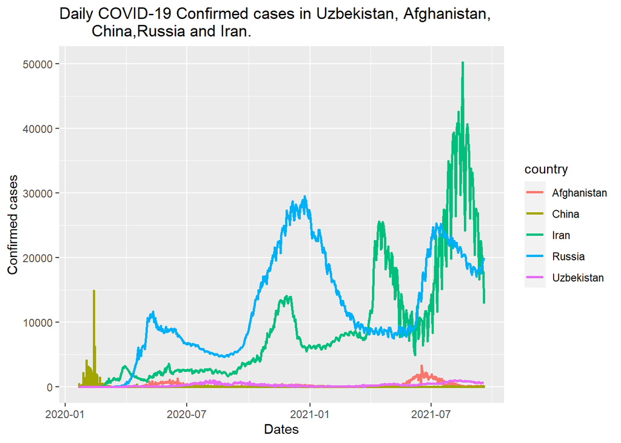

Figure 06:Daily COVID-19 confirmed cases in Uzbekistan,Afganistan,China,Russia and Iran. Figure 06 shows that the confirmed cases of Iran and Russia was quite increasing middle of the 2020 but gradually increasing untill the August 2021 compared to other countries. But China hasn’t confirmed corona cases since March.. Most of confirmed country was Iran in that short time period. When comparing with Uzbekistan and Afghanistan confirmed corona cases is lower than other countries.

#### 2.4.2 Comparison of daily COVID-19 death cases in Uzbekistan,Afghanistan,China ,Russia and Iran.

First the death cases of four countries were selected.

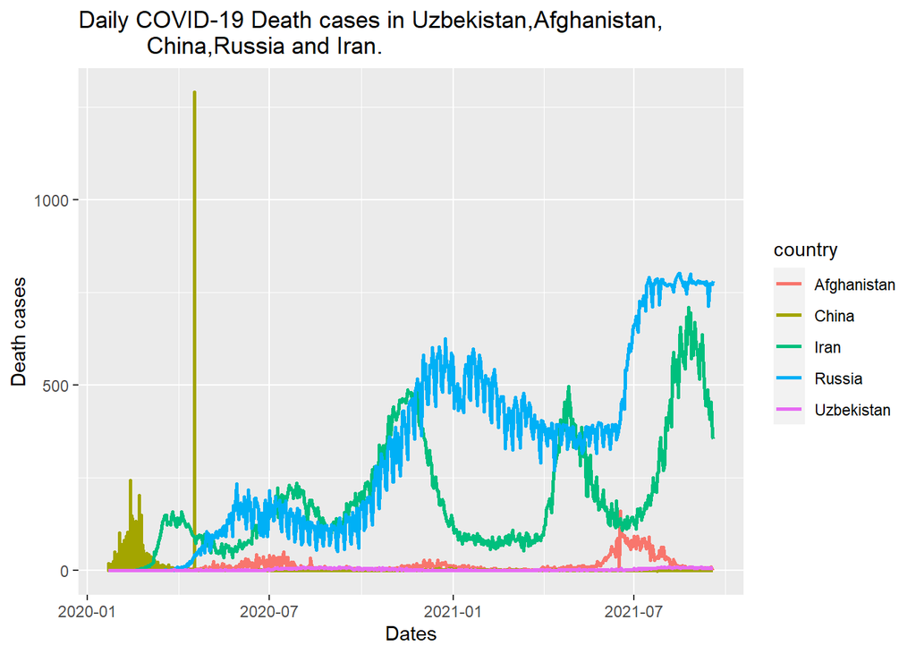

Figure 07: Daily COVID-19 death cases in Uzbekistan,Afghanistan,China,Russia and Iran.

Figure 07 shows that Iran and Russia death cases have increased gradually .But another counrtries haven’t biggest death cases after 2020.when compared with uzbekistan and Afghanistan,China had death cases from begining of 2020.but it has decreassed.highest death cases shows as 1290 in china.

#### 2.4.3 Comparison of daily recovered COVID-19 cases in Uzbekistan, Afghanistan,China,Russia and Iran.

First the recoverd cases of four countries were selected.

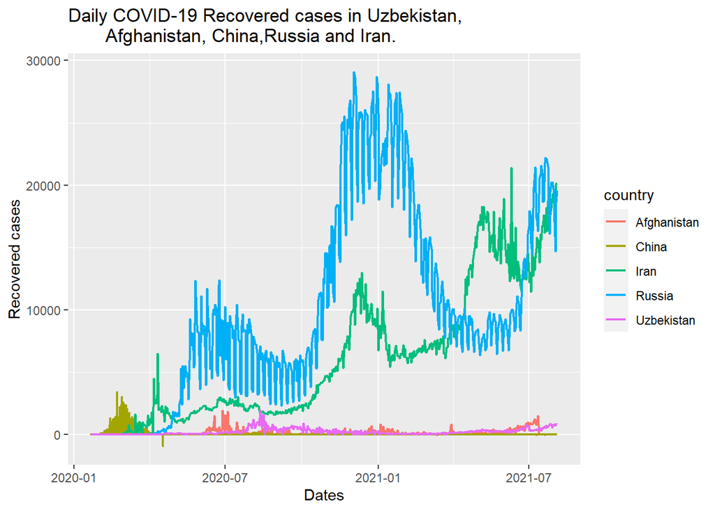

Figure 08:Daily COVID-19 recovered cases in Uzbekistan,Afghanistan,China,Russia and Iran. Figure 08 show that also Russia have high recovered cases. China have a high recovered cases on earlier of 2020 but it has decreased in short period. when comapring with china and Russia Uzbekistan and Afghanistan have also low curves. Limitations Data on testing and hospital facilities could be helpful in identifying the effectiveness of the decisions taken.

There is also the case of readjustment of cases which has happened several times in the data, thereby resulting in negative cases.

## **3. Conclusions**

Coronavirus disease 2019 is identified in December 2019 in Wuhan, Hubei but It is increased speedily in January to March. However, it is directly affected to the other countries. At that time, most of countries in Asia had high risk but all countries did not expect serious situations like this. China is the country which has largest population plus they have strong health facilities and modern technologies. After the virus entered to the population they taken action to preventing virus.

Uzbekistan goverment was control corona virus when comapred with other countries. There are some drawbacks to be kept in mind when analyzing this study’s findings. Due to insufficient laboratory resources, numbers of confirmed laboratory cases reported do not represent the current apidemic. The government can sometimes be hiding the actual counts of cases.

## **4. Discussion**

The dataset is loaded by coronavirus dataset given in the package R.Uzbekistan dataset is obtained by it. The dataset has null values for recovered cases from 2021.08.05 to 2021.09.18.Since data are important in analysis we cannot replace that values because this is actual data of certain country about covid pandemic,and also we cannot replace it as zero because of zero is also a value in this analysis.Hence we removed that entire rows and conduct the analysis from 2020.01.22 to 2021.08.04. The results of Uzbekistan were compared with those of Afghanistan,China,Russia and Iran because of that countries near to Uzbekistan. It was clearly visible that while the outcomes for Uzbekistan,Afghanistan and china were within the same spectrum the outcomes for the Russia and Iran showed drastically different results.Obviously it is a well known fact that the Russia and Iran is heavily affected by the pandemic.This definitely plays a role in the outcomes for the both countries.But it should be noted that Uzbekistan is a significantly small country when compared to the Russia.Therefore it is not quite accurate to make a direct comparison between the results for Uzbekistan and the Russia.Ideally an adjustment should be made to the outcomes of in order to capture the size difference between the two countries.

## **5. References.**

1. https://fpc.org.uk/covid-19-actions-taken-in-uzbekistan/
2. https://reliefweb.int/report/uzbekistan/supporting-uzbekistan-throughout-covid-19-pandemic
3. https://thediplomat.com/2020/09/uzbekistans-covid-19-response-exposes-tashkents-reform-successes-and-failures/
4. https://www.britannica.com/place/Uzbekistan
5. https://www.undp.org/press-releases/uzbekistans-health-care-system-economy-hit-hard-covid-19